# communicating-insights--1-executive-report

←Back to the bookChapter 157 · Report 1 · Executive One-Pager

Chapter 157 · Communicating Results · Report 1 of 3

Analysis for the Executive Report: Quarterly Sales Performance

This notebook does the analysis and builds the visuals for an executive briefing. It stops at the evidence; the finished report is a separate, human-authored Word document that a statistician writes around these exact charts. Download it from the chapter.

```python
import numpy as np, pandas as pd
import matplotlib as mpl, matplotlib.pyplot as plt
# A clean house style for report-ready figures: no chartjunk, strong titles, muted grid.
mpl.rcParams.update({"figure.dpi":110,"font.size":11,"axes.spines.top":False,"axes.spines.right":False,
    "axes.grid":True,"grid.alpha":0.22,"axes.titleweight":"bold","axes.titlesize":12.5,
    "axes.titlelocation":"left","axes.titlepad":10})
ROSE, INK, MUT, GR, RD = "#be123c", "#1a2138", "#64748b", "#16a34a", "#dc2626"
BASE = "https://raw.githubusercontent.com/johnfisher-ai/Statistics-Data-Science-AI-Visual-Book/main/data/"
fn = "communicating-insights--company-data.xlsx"
def load(sheet):
    try: return pd.read_excel("../../data/" + fn, sheet_name=sheet)
    except FileNotFoundError: return pd.read_excel(BASE + fn, sheet_name=sheet)
```

## Step 1 · Load and analyze

Read the monthly sales sheet and compute the handful of numbers an executive actually needs: the headline total, the trend, and the regional split.

```python
sales = load("SalesMonthly")
sales["quarter"] = "Q" + pd.PeriodIndex(sales.month, freq="M").quarter.astype(str)
total_rev = sales.revenue.sum(); total_orders = int(sales.orders.sum()); aov = total_rev/total_orders
byq = sales.groupby("quarter").revenue.sum()
growth = byq["Q4"]/byq["Q1"] - 1
byregion = sales.groupby("region").revenue.sum().sort_values(ascending=False)
print(f"total revenue ${total_rev:,.0f} | orders {total_orders:,} | AOV ${aov:.2f} | Q4 vs Q1 {growth:+.1%}")
print(byregion.round(0).to_string())
```

```
total revenue $2,154,938 | orders 22,576 | AOV $95.45 | Q4 vs Q1 +12.0%
region
North      535879.0
West       489393.0
East       422289.0
South      379930.0
Central    327447.0
```

## Step 2 · Build the two visuals

One trend chart and one ranked bar. Each title states the point so the figures stand alone.

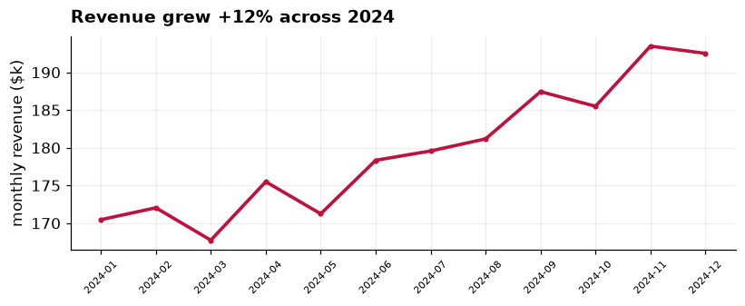

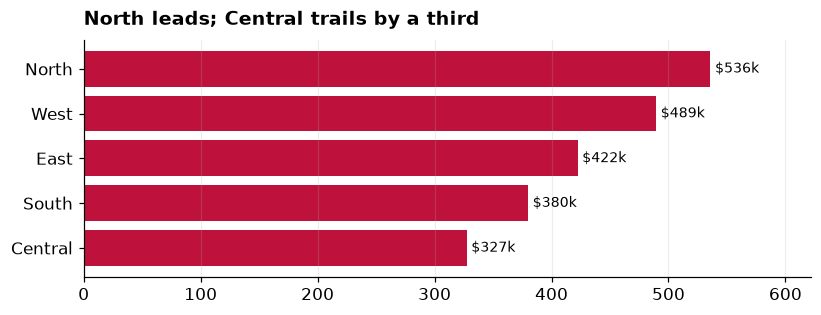

```python
fig_trend, ax = plt.subplots(figsize=(7.6, 3.2))
m = sales.groupby("month").revenue.sum()/1000
ax.plot(m.index, m.values, color=ROSE, lw=2.4, marker="o", ms=3)
ax.set_title(f"Revenue grew {growth:+.0%} across 2024"); ax.set_ylabel("monthly revenue ($k)")
ax.tick_params(axis="x", rotation=45, labelsize=7); plt.tight_layout(); plt.show()

fig_reg, ax = plt.subplots(figsize=(7.6, 3.0))
r = byregion.sort_values()/1000
ax.barh(r.index, r.values, color=ROSE)
for y,v in enumerate(r.values): ax.text(v+4, y, f"${v:,.0f}k", va="center", fontsize=9)
ax.set_title("North leads; Central trails by a third"); ax.set_xlim(0, r.max()*1.16)
ax.grid(axis="y", visible=False); plt.tight_layout(); plt.show()
```

## Step 3 · The summary table for the report

The two figures plus this compact KPI table are the evidence the report is built from. A clean table like this is what a statistician drops into the document alongside the charts.

```python
kpi = pd.DataFrame({"Metric":["Total revenue","Orders","Average order value","Q4 vs Q1 growth","Top region"],
                   "Value":[f"${total_rev:,.0f}", f"{total_orders:,}", f"${aov:.2f}", f"{growth:+.0%}", "North"]})
kpi
```

|  | Metric | Value |
| --- | --- | --- |
| 0 | Total revenue | $2,154,938 |
| 1 | Orders | 22,576 |
| 2 | Average order value | $95.45 |
| 3 | Q4 vs Q1 growth | +12% |
| 4 | Top region | North |

### From analysis to report

This notebook is the **analysis**: it loads the data, computes the numbers, and produces the two figures and the table. It deliberately stops there. The finished **report** is a separate, human-authored Word document, a statistician writing for a non-technical reader, who pastes these exact visuals in and explains what they mean in plain language, laid out inverted-pyramid style with the recommendation first. Download it from the chapter to see the difference between raw output and a written argument.

←Back to the bookChapter 157 · Report 1 · Executive One-Pager